# Chocolate

**Comments to Critiquers:**

## Background

Making good chocolate can be a complicated task. There are many factors involved and at times it can be difficult to quantify or rank elements that impact the chocolates quality.

A dataset has been gathered from Kaggle.com on chocolate and its sources, quality, and rating. This dataset will be used in this analysis to answer the following questions:

- What are the ratings chocolates receive?
- Do the chocolate ratings increase as the percentage of cocoa in the chocolate increases?

For this analysis we will be comparing the qualitative Cocao ratings (rounded to the nearest whole number) to the quantitative percentage of Cocao in the chocolate. Since the ratings are ordinal numbers we’ll need to conduct a nonparametric test. I will be using a Kruskal-Wallis Test as a result.

Our hypotheses are as follows and our significance level will be .05.

$$H_0: \text{Each rating group has the same distribution in cocao percentages.}$$
$$H_a: \text{At least one rating group has a cocao percentage distribution that is stochastically different than the others.}$$

### Show Data

```r
library(readr)
choc <- read_csv("../../Data/Chocolate.csv")
```

```r
choc2 <- select(choc,
                c(Rating, Cocao)
                ) %>%
  mutate(Cocao_percent = as.numeric(gsub("%", "", choc$Cocao)) / 100,
         Rating = as.numeric(Rating))
```

```r
datatable(choc2)
```

|  | Rating | Cocao | Cocao_percent |
| --- | --- | --- | --- |
| 1 | 3.75 | 63% | 0.63 |
| 2 | 2.75 | 70% | 0.7 |
| 3 | 3 | 70% | 0.7 |
| 4 | 3.5 | 70% | 0.7 |
| 5 | 3.5 | 70% | 0.7 |
| 6 | 3.5 | 70% | 0.7 |
| 7 | 4 | 70% | 0.7 |
| 8 | 2.75 | 70% | 0.7 |
| 9 | 3.25 | 70% | 0.7 |
| 10 | 3.75 | 70% | 0.7 |

[output cut: 1784 more lines]

## Analysis

**Chocolate Rating Summary**

```r
favstats(choc2$Rating) %>% pander()
```

| min | Q1 | median | Q3 | max | mean | sd | n | missing |
| --- | --- | --- | --- | --- | --- | --- | --- | --- |
| 1 | 2.812 | 3.25 | 3.5 | 5 | 3.185 | 0.4778 | 1794 | 0 |

**Chocolate Percentage Summary**

```r
favstats(choc2$Cocao_percent) %>% pander()
```

| min | Q1 | median | Q3 | max | mean | sd | n | missing |
| --- | --- | --- | --- | --- | --- | --- | --- | --- |
| 0.42 | 0.7 | 0.7 | 0.75 | 1 | 0.717 | 0.06325 | 1794 | 0 |

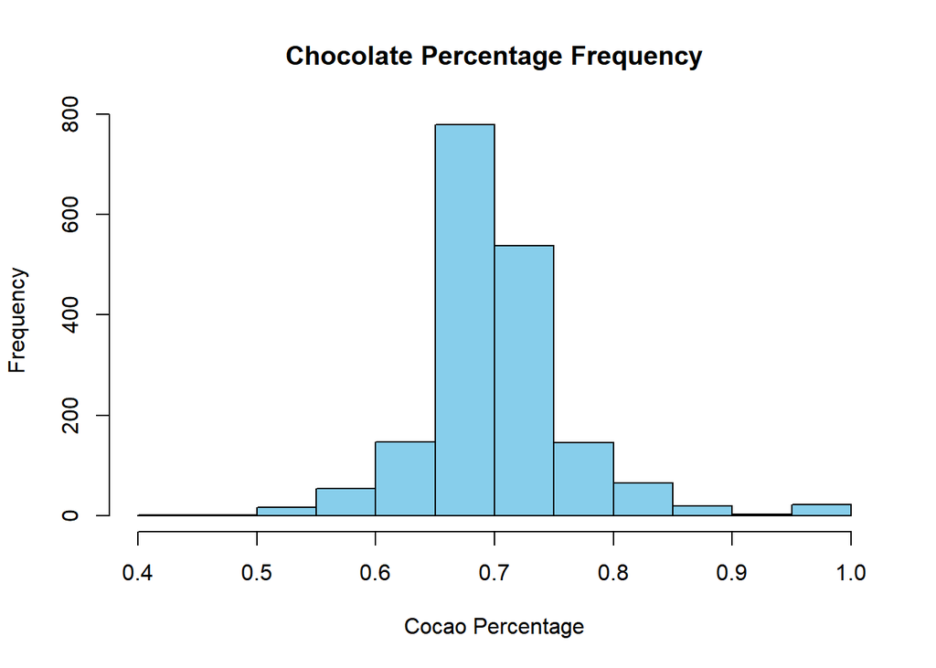

```r
hist(choc2$Cocao_percent,
     breaks = 12,
     col = "skyblue",
     main = "Chocolate Percentage Frequency",
     xlab = "Cocao Percentage")
```

The boxplot seems to show that the cocao percentage approaches 70% as the ratings approach a perfect score of 5.

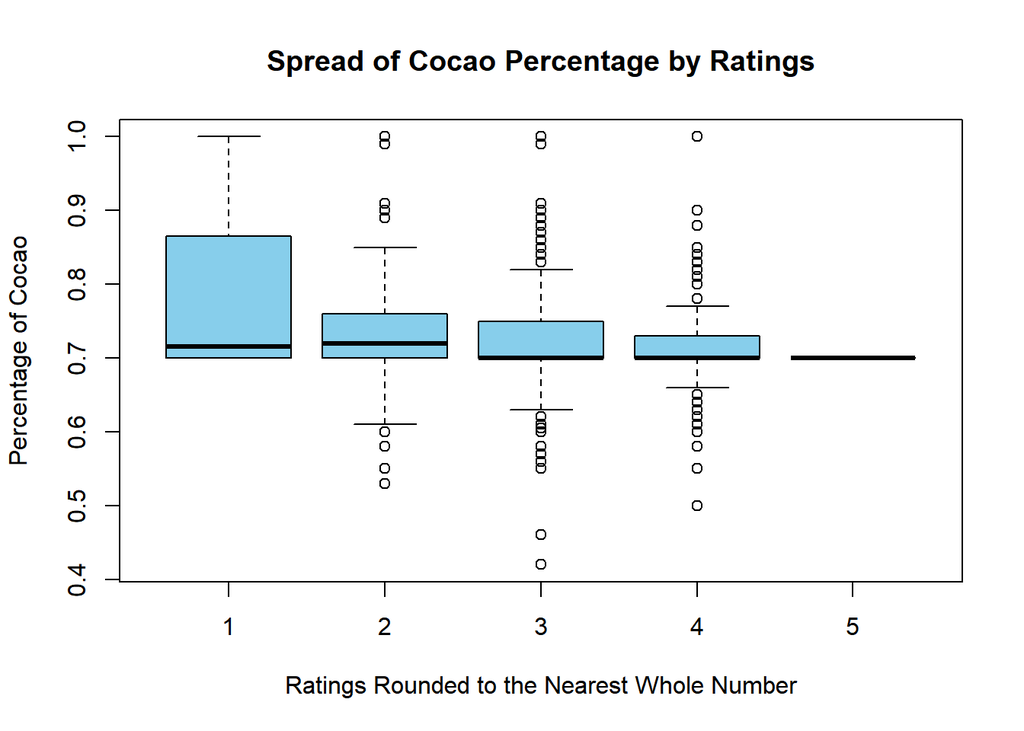

```r
boxplot(Cocao_percent ~ round(Rating, 0),
        data = choc2,
        col = "skyblue",
        main = "Spread of Cocao Percentage by Ratings",
        ylab = "Percentage of Cocao",
        xlab = "Ratings Rounded to the Nearest Whole Number")
```

Let us confirm this with a Kruskal Wallis Test. This will confirm what the p-value will be. If it is lower than our level of significance we can reject the nulll.

**Kruskal Test**

```r
kruskal.test(Cocao_percent ~ as.factor(round(Rating, 0)),
             data = choc2) %>% pander()
```

Kruskal-Wallis rank sum test: `Cocao_percent` by `as.factor(round(Rating, 0))`

| Test statistic | df | P value |
| --- | --- | --- |
| 24.82 | 4 | 5.46e-05 * * * |

With a p-value of 5.46e-05 we know that there is sufficient evidence to reject the null hypothesis. That means that, one of these five scores come from a different cocao percentage distribution.

Though this test will not prove which of the five scores is stochastically different, we do know that the distributions did shrink as we approached the Rating of 5. We can see that more clearly in the below summary.

```r
favstats(Cocao_percent ~ as.factor(round(Rating, 0)),
         data = choc2,
         caption = "Numeric Summary")[,-10] %>% pander()
```

Table continues below

| as.factor(round(Rating, 0)) | min | Q1 | median | Q3 | max | mean |
| --- | --- | --- | --- | --- | --- | --- |
| 1 | 0.7 | 0.7 | 0.715 | 0.7975 | 1 | 0.7825 |
| 2 | 0.53 | 0.7 | 0.72 | 0.76 | 1 | 0.7379 |
| 3 | 0.42 | 0.7 | 0.7 | 0.75 | 1 | 0.7177 |
| 4 | 0.5 | 0.7 | 0.7 | 0.73 | 1 | 0.7102 |
| 5 | 0.7 | 0.7 | 0.7 | 0.7 | 0.7 | 0.7 |

| sd | n |
| --- | --- |
| 0.1457 | 4 |
| 0.09684 | 186 |
| 0.06501 | 903 |
| 0.04527 | 699 |
| 0 | 2 |

## Interpretation

Generally speaking, it seems that chocolate ratings go up as the percentage of chocolate per bar approaches 70%. Chocolate companies should try to keep their cocao percentages means around there if they are looking to have high ratings on their chocolate itself.

Some might argue that the two ratings of 5 are not sufficiently large to be representative of chocolate bars at that high of a rating and though this is true, removing those two values (or that rating in general) wouldn’t change that the standard deviations decreases for the other four ratings as we approach the fifth rating.

At this point, it might be worthwhile to conduct an ANOVA and see what other factors may have impact the ratings.